# HDAT9600 Final Team Assignment

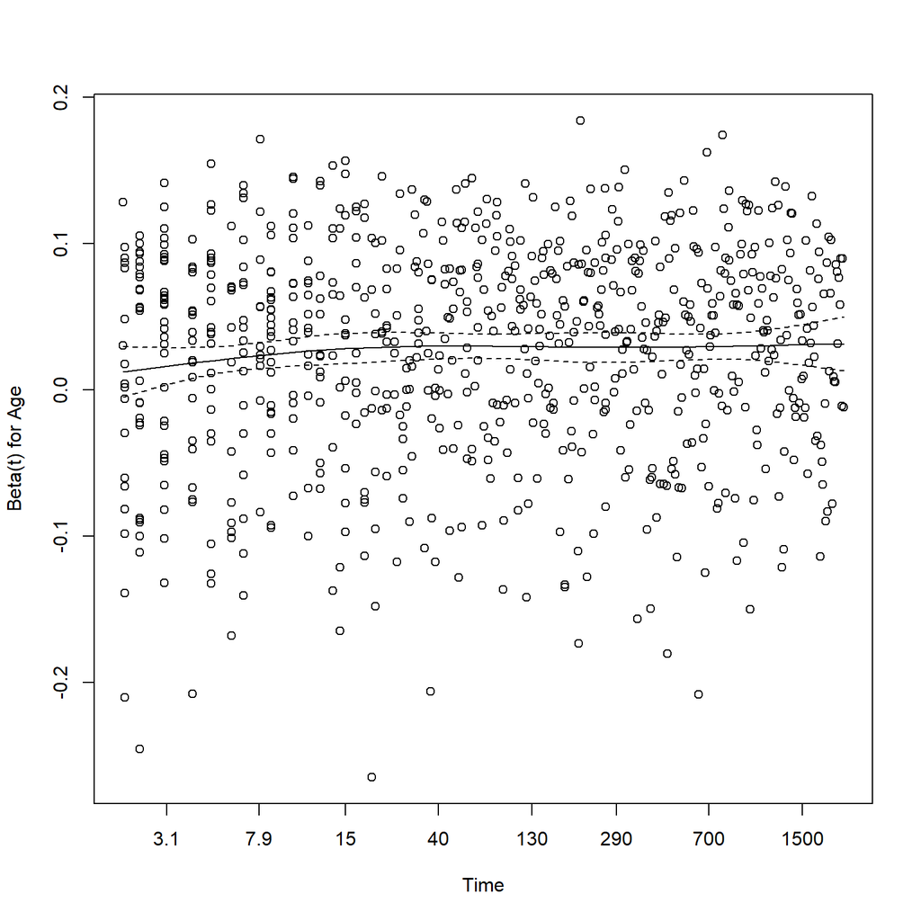

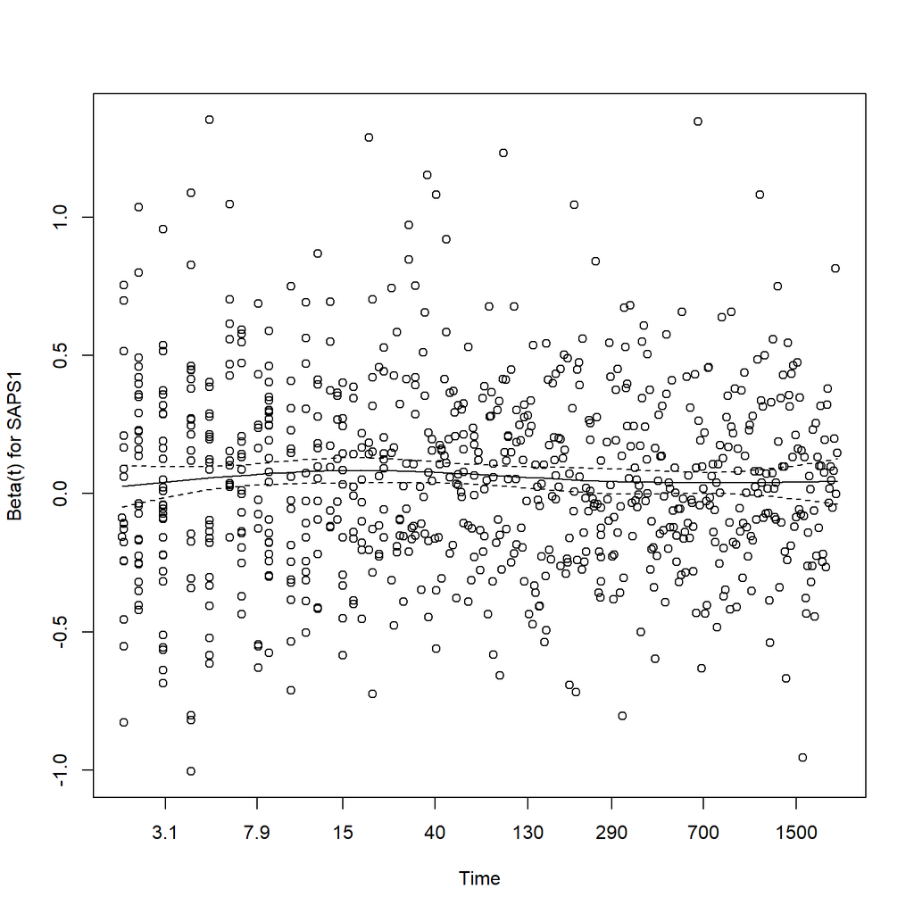

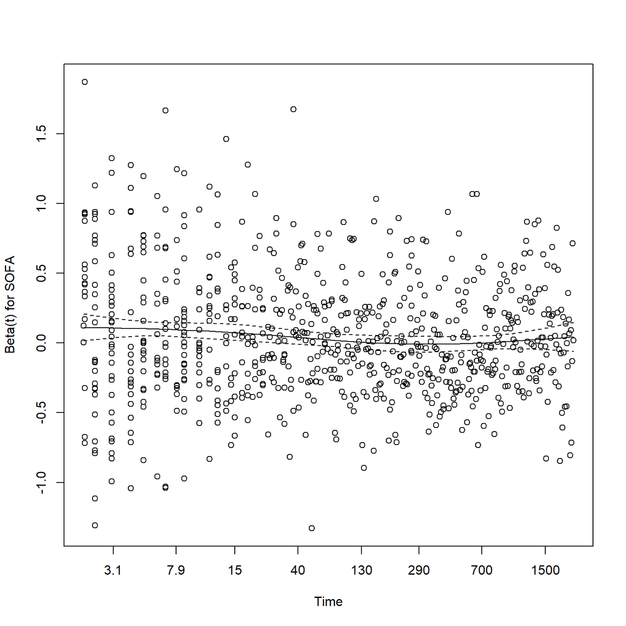

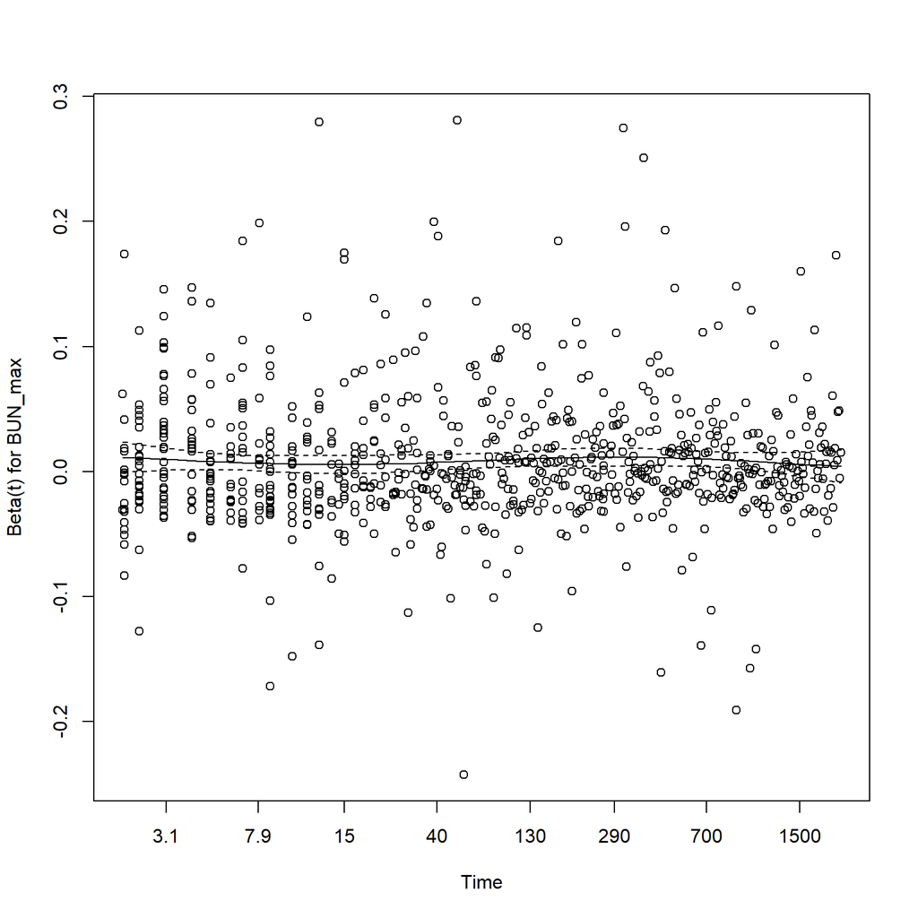

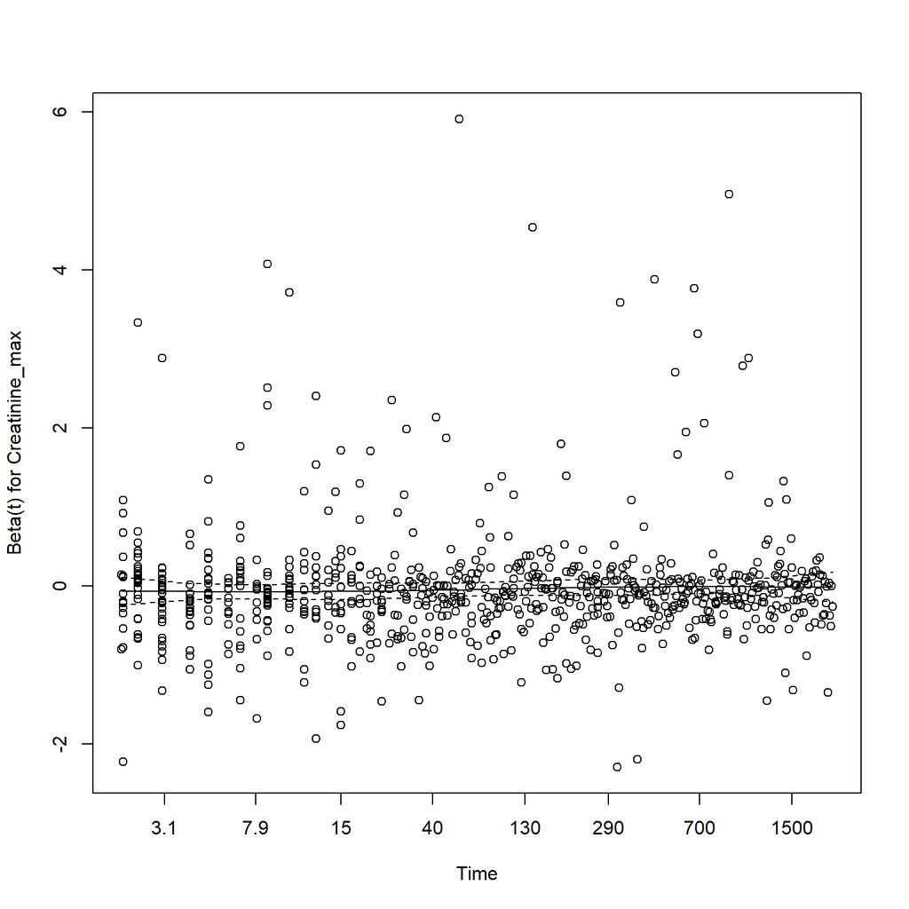

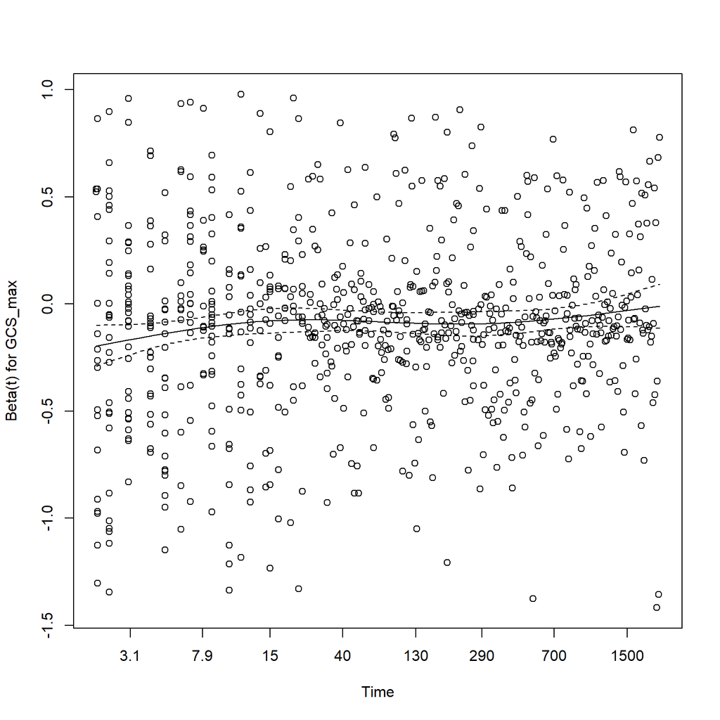

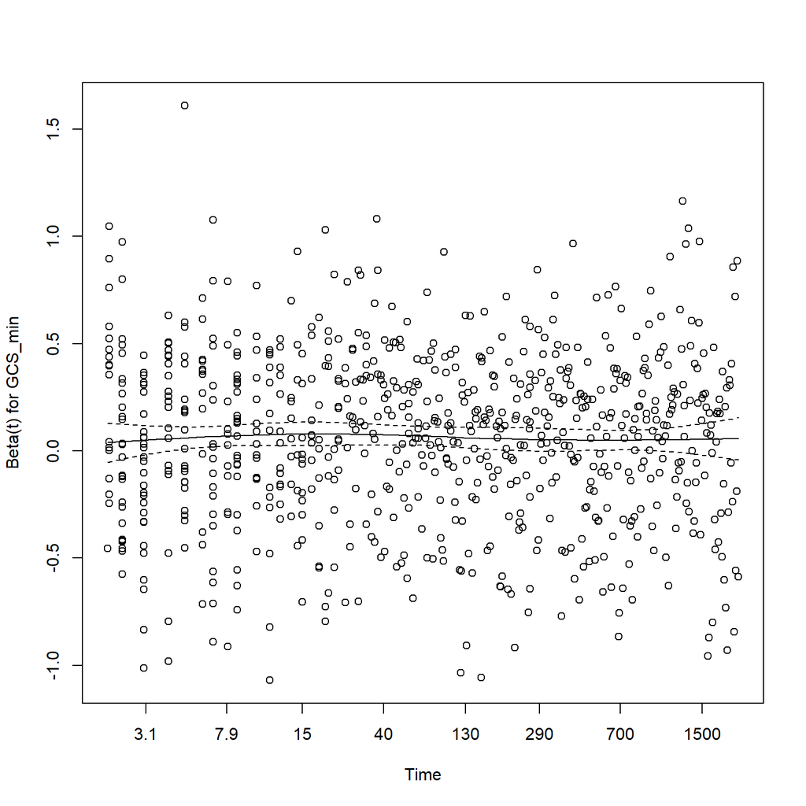

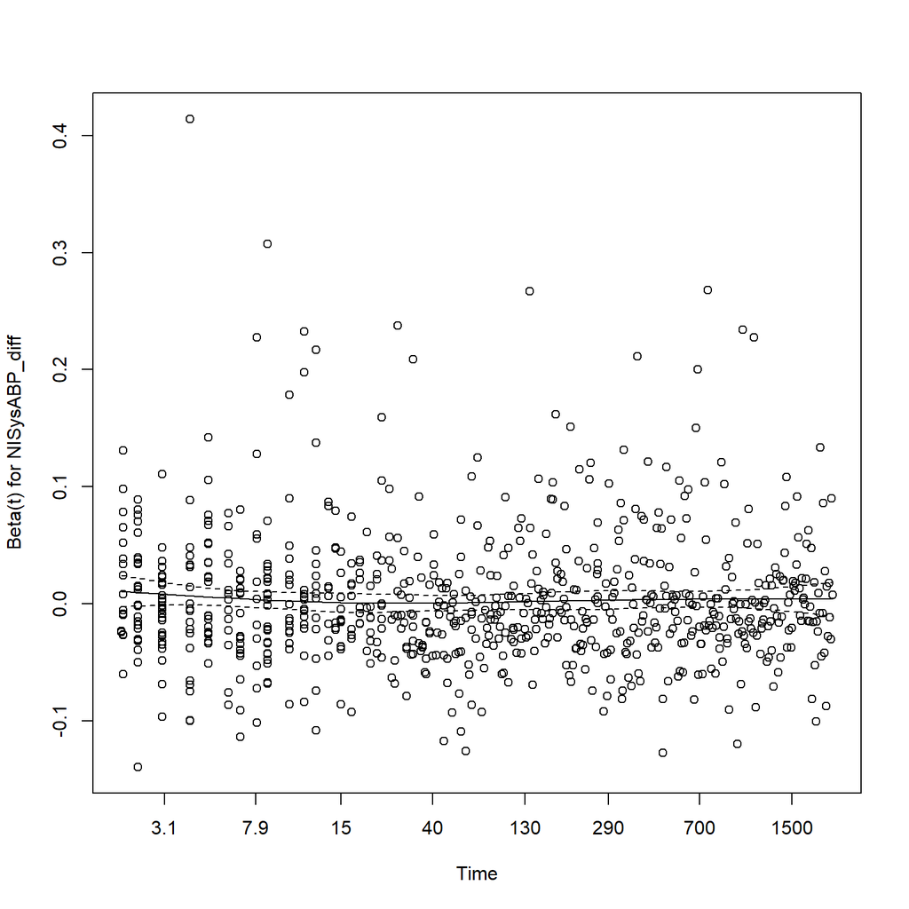

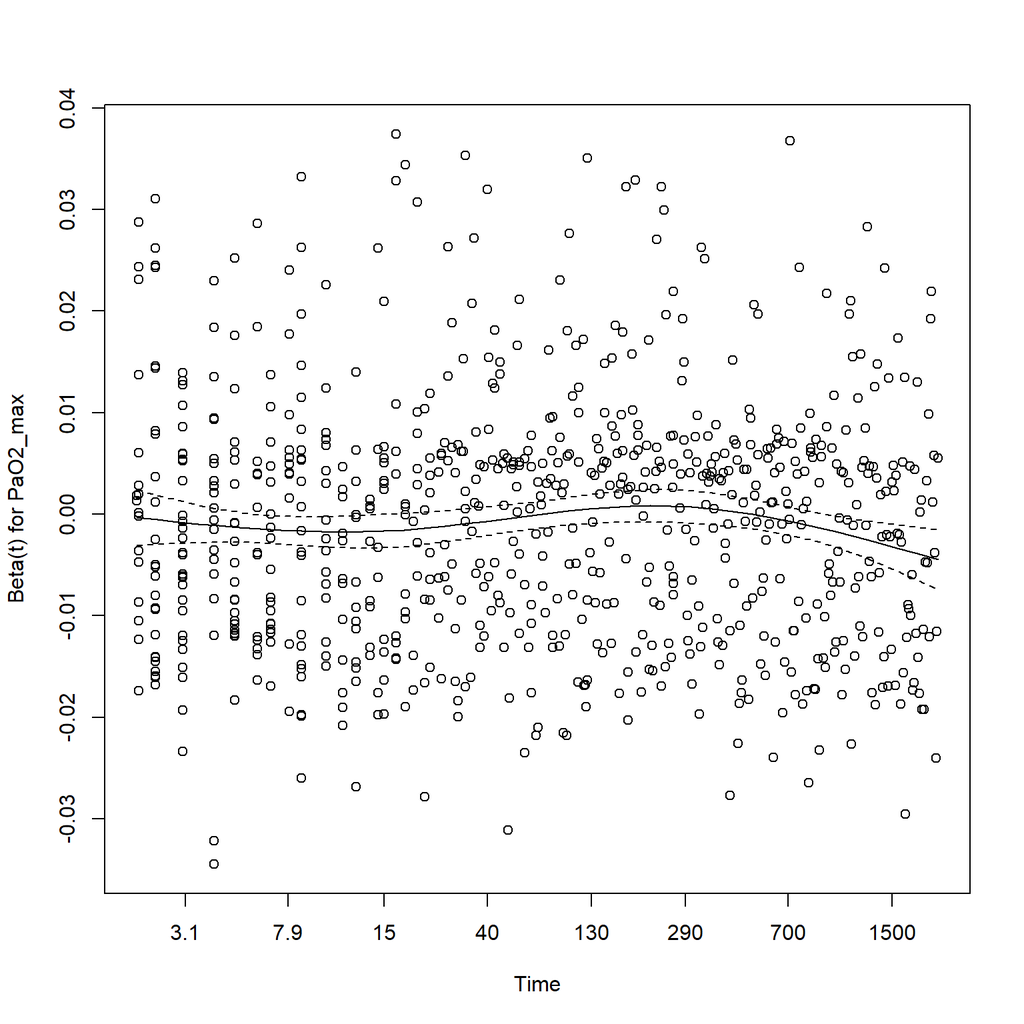

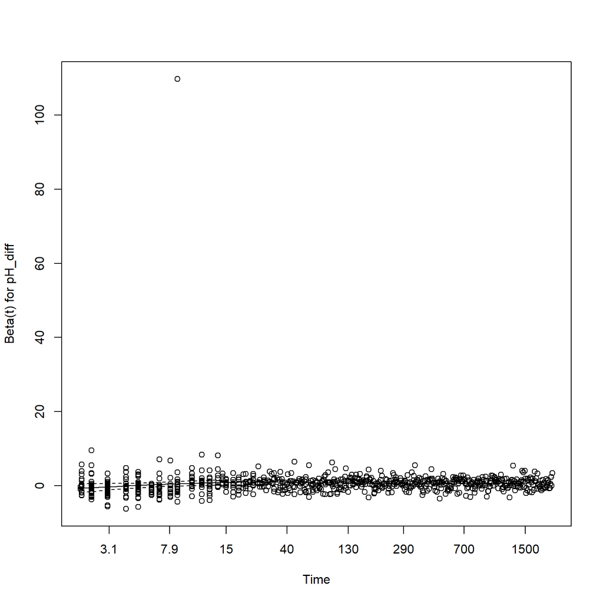

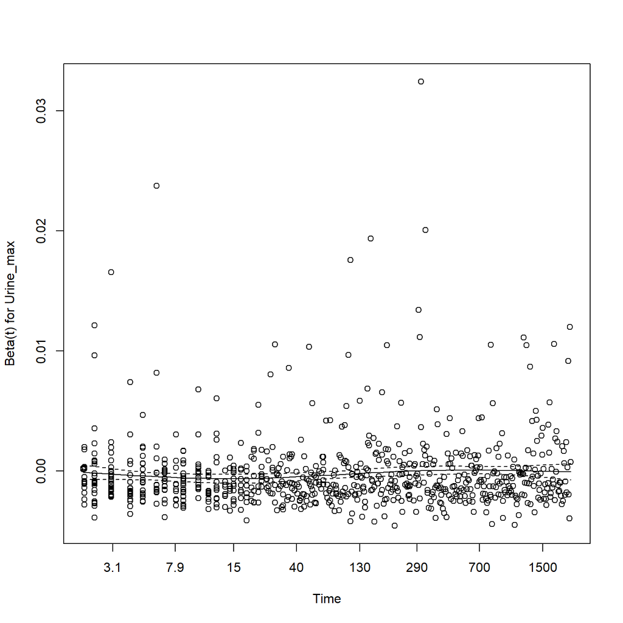

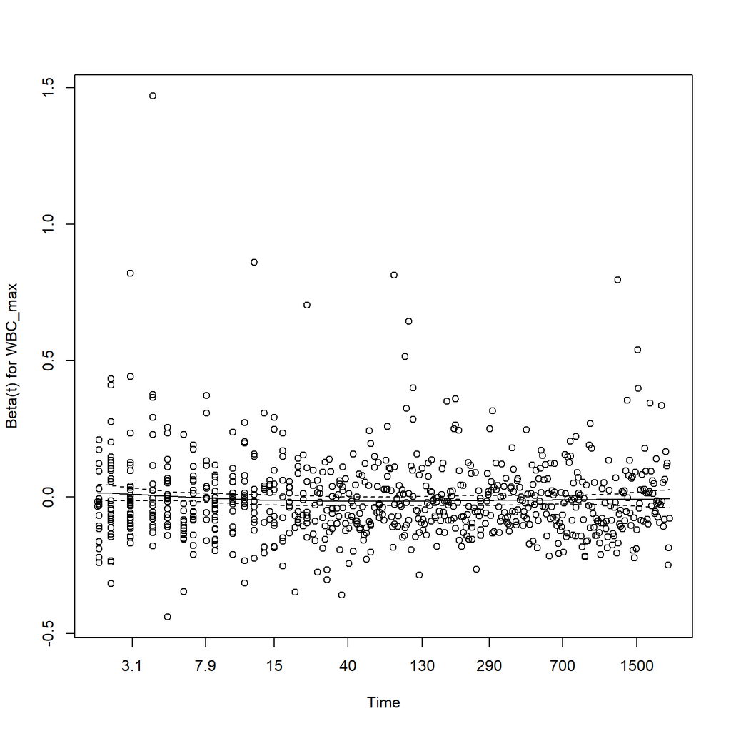

[1 more figures not shown]

```r
plot(cox.zph_res_df0) #diagnostic plots
```

```r
# Perform stepwise selection based on AIC
stepwise_cox_model_df0 <- stepAIC(cox_model, direction = "both")
```

```
## Start:  AIC=10934.26
## Surv(Days, Status) ~ Age + SAPS1 + SOFA + BUN_max + Creatinine_max +
##     GCS_max + GCS_min + NISysABP_diff + PaO2_max + pH_diff +
##     Urine_max + WBC_max + ICUType
##
##                  Df   AIC
## <none>              10934
## - Creatinine_max  1 10935
## - WBC_max         1 10935
## - NISysABP_diff   1 10935
## - PaO2_max        1 10937
## - pH_diff         1 10937
## - Urine_max       1 10940
## - SOFA            1 10941
## - GCS_min         1 10950
## - BUN_max         1 10951
## - SAPS1           1 10955
## - ICUType         3 10958
## - GCS_max         1 10969
## - Age             1 11040
```

```r
kable(summary(stepwise_cox_model_df0)$coefficients, caption = "Summary of Stepwise Cox Model")
```

Summary of Stepwise Cox Model

|  | coef | exp(coef) | se(coef) | z | Pr(>\|z\|) |
| --- | --- | --- | --- | --- | --- |
| Age | 0.0267929 | 1.0271550 | 0.0026999 | 9.923789 | 0.0000000 |
| SAPS1 | 0.0566644 | 1.0583006 | 0.0117830 | 4.808998 | 0.0000015 |
| SOFA | 0.0437166 | 1.0446863 | 0.0149756 | 2.919192 | 0.0035094 |
| BUN_max | 0.0083768 | 1.0084120 | 0.0018808 | 4.453905 | 0.0000084 |
| Creatinine_max | -0.0426158 | 0.9582795 | 0.0271831 | -1.567729 | 0.1169444 |
| GCS_max | -0.0911256 | 0.9129030 | 0.0148177 | -6.149763 | 0.0000000 |
| GCS_min | 0.0608879 | 1.0627798 | 0.0143255 | 4.250312 | 0.0000213 |
| NISysABP_diff | 0.0035230 | 1.0035292 | 0.0020764 | 1.696680 | 0.0897572 |
| PaO2_max | -0.0009089 | 0.9990915 | 0.0004284 | -2.121613 | 0.0338703 |
| pH_diff | 0.5444756 | 1.7237042 | 0.1861991 | 2.924158 | 0.0034539 |
| Urine_max | -0.0002601 | 0.9997399 | 0.0000964 | -2.697619 | 0.0069837 |
| WBC_max | -0.0077808 | 0.9922494 | 0.0048667 | -1.598775 | 0.1098707 |
| ICUTypeCardiac Surgery Recovery Unit | -0.6583563 | 0.5177016 | 0.1530792 | -4.300757 | 0.0000170 |
| ICUTypeMedical ICU | 0.0595781 | 1.0613886 | 0.1055182 | 0.564624 | 0.5723295 |
| ICUTypeSurgical ICU | -0.1843512 | 0.8316437 | 0.1215965 | -1.516089 | 0.1294968 |

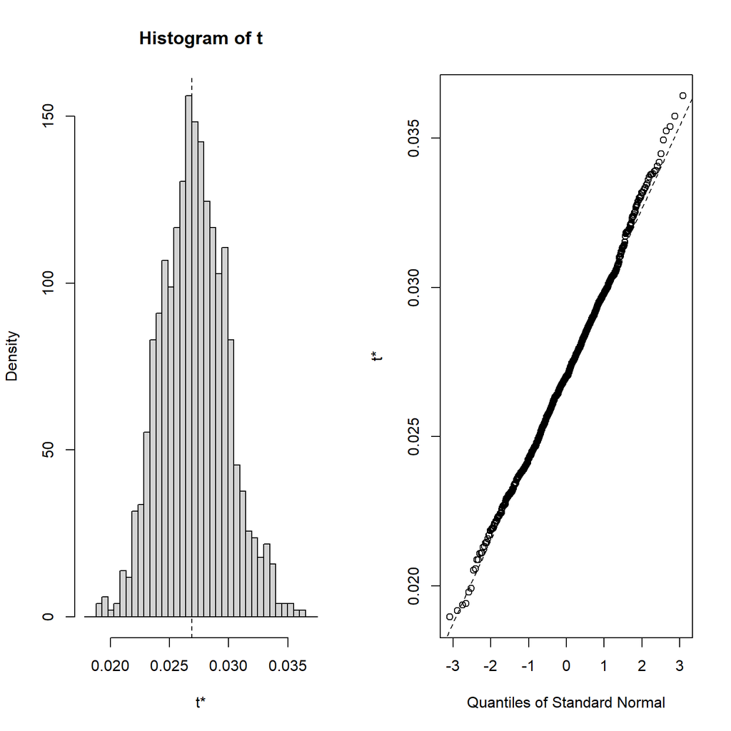

```r
# bootstrapping to validate the model (fits a Cox proportional hazards model to a subset of data)
coxph_boot <- function(data, indices) {
  d <- data[indices,] # allows boot to select sample
  fit <- coxph(Surv(Days, Status) ~ Age + SAPS1 + SOFA + BUN_max + Creatinine_max + GCS_max + GCS_min + NISysABP_diff + PaO2_max + pH_diff + Urine_max + WBC_max + ICUType, data = d)
  return(coef(fit)) #returns the coefficients of the fitted model
}

# Bootstrapping with 1000 resamples
results_boot <- boot(icu_patients_df1_cleaned, coxph_boot, R=1000)
plot(results_boot)
```

- **Histogram**: Shows the distribution of one of the bootstrap estimates (usually the first coefficient if not specified), helps visualize the variability and bias of the estimate. In here, the distribution looks symmetric about the mean, suggesting that the bootstrap samples do not show much bias. - **Quantile-Quantile (QQ) plot**: This plot compares the quantiles of the bootstrap estimates against the quantiles of a standard normal distribution. The points lie close to the diagonal line, which implies that the distribution of the bootstrap estimates is approximately normal.

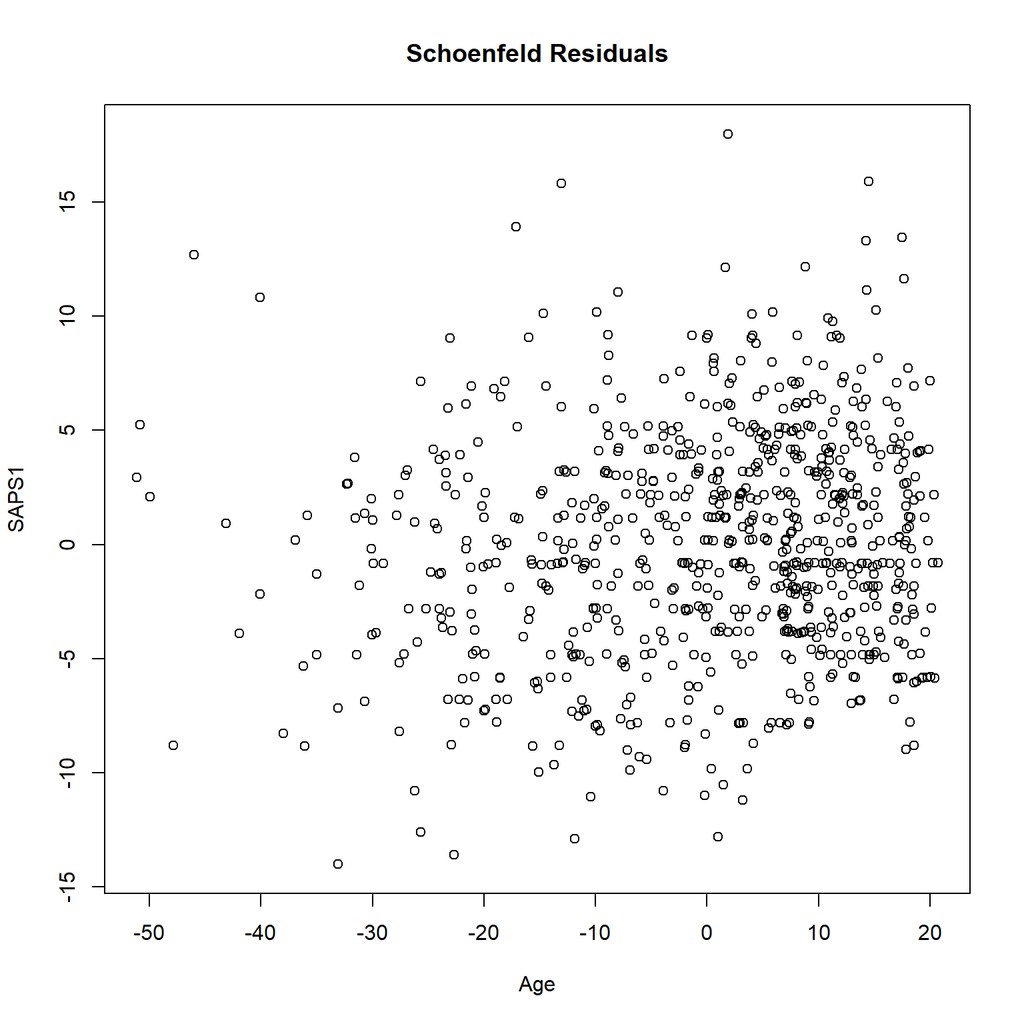

```r
# Plot diagnostics
# Compute Schoenfeld residuals
schoenfeld_res <- residuals(stepwise_cox_model, type = "schoenfeld")

# Compute Martingale residuals
martingale_res <- residuals(stepwise_cox_model, type = "martingale")

# Compute deviance residuals
deviance_res <- residuals(stepwise_cox_model, type = "deviance")

# Compute score residuals
score_res <- residuals(stepwise_cox_model, type = "score")

# Plotting Schoenfeld residuals
plot(schoenfeld_res, main = "Schoenfeld Residuals")
```

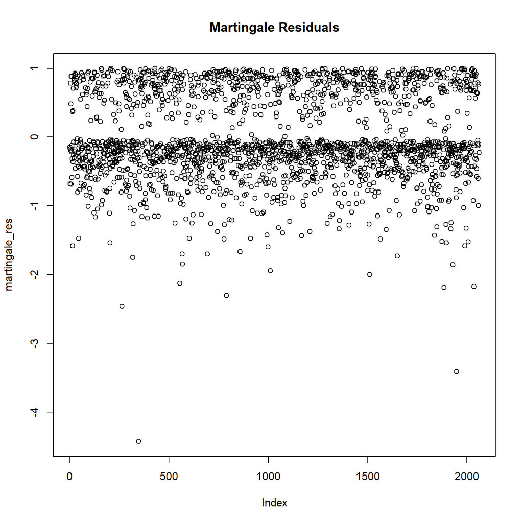

```r
# Plotting Martingale residuals
plot(martingale_res, main = "Martingale Residuals")
```

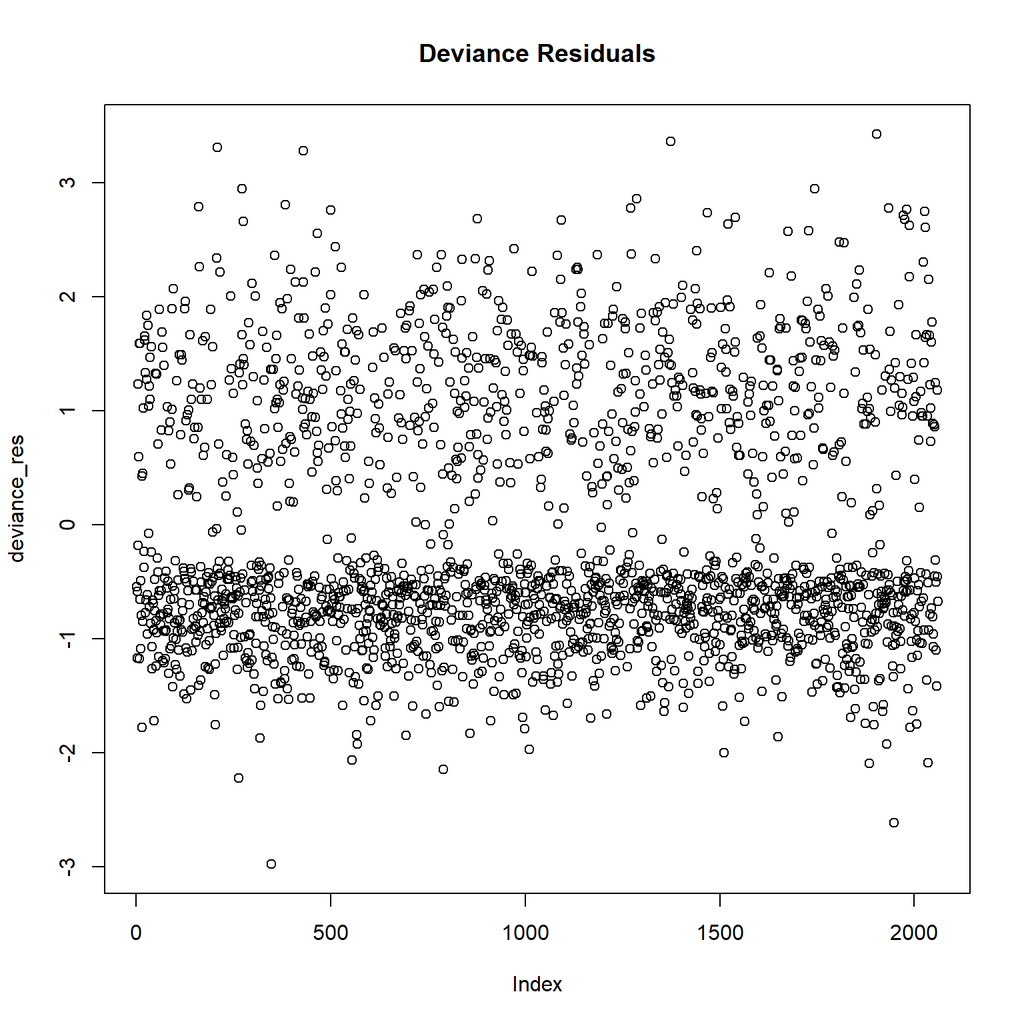

```r
# Plotting Deviance residuals
plot(deviance_res, main = "Deviance Residuals")
```

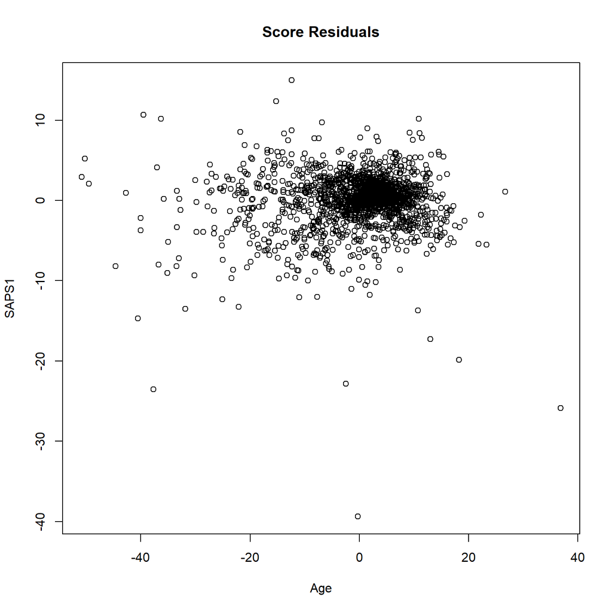

```r
# Plotting Score residuals
plot(score_res, main = "Score Residuals")
```